# ESM 204 - Assignment 2

Kirsten White, Van Gonzales, Max Settineri

April 24, 2022

# Part 1

### Plotting Marginal Cost Curves by Irrigation District

The dataset contains estimates of the marginal cost of reducing water usage in each of the four irrigation districts (Kern, Mojave, Antelope, and Ventura) at different levels of reduction (in Acre Feet).

For each irrigation district, plot the marginal abatement cost data (from the data provided) and estimate a linear regression model with zero intercept. These estimated linear regressions will be your estimates of the marginal abatement cost curve (one for each irrigation district), which you will use for the remainder of this analysis.

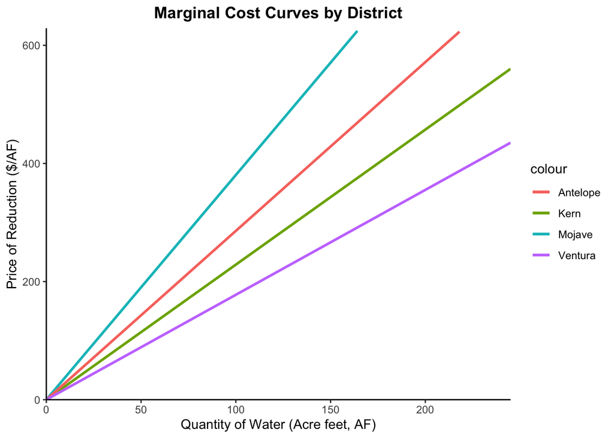

# Part 2

### Plotting Water Demand Curves by Irrigation District

Using your estimated marginal abatement cost curves, derive each district’s demand curve for water. In other words, how much would each district be willing to pay for the right to use the first AF of water, second AF, etc.? Plot each district’s demand curve on a single graph. Which sector is willing to pay the most for the first AF of water?

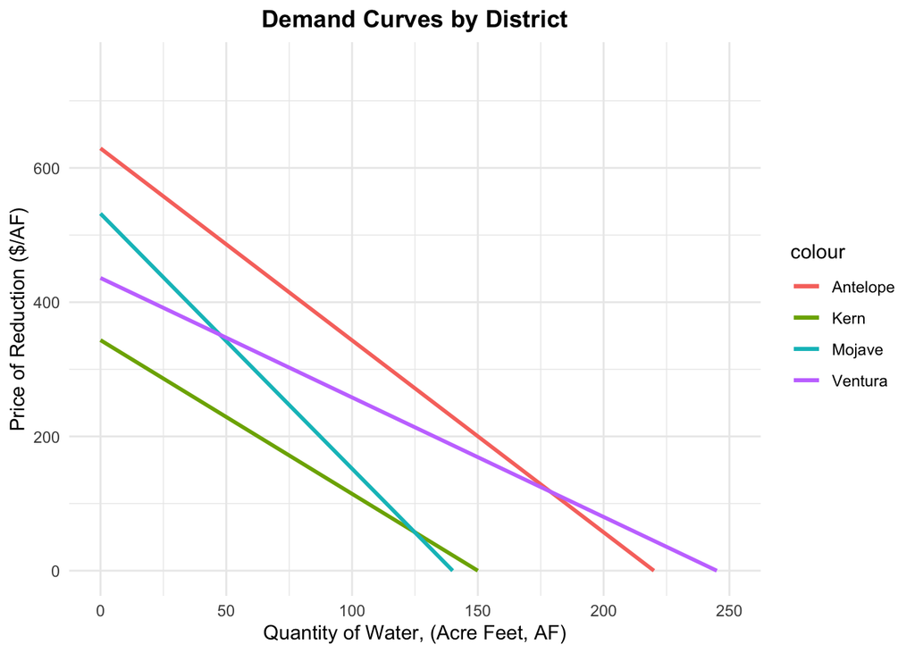

Based off of the graph above, Antelope is willing to pay the most for the first unit of abatement.

# Part 3

### Evaluating Policy Considerations

Three different policies for reducing water use among these irrigation districts will be analyzed.

In total, these irrigation districts will need to reduce water consumption from the current 755 AF down to 500 AF. For each intervention listed below, perform the following calculations: (1) calculate the stringency of the policy (defined below for each intervention) required to achieve the 500 AF target, (2) calculate the total cost of meeting the target using that approach, (3) calculate the cost to each district, and (4) calculate the tax revenue generated.

### **Policy A - Cap Without Trade**

Reduce each district’s water use by the same fraction (e.g., 1/3 of current baseline use), so the 500 AF target is met. Trade is not allowed. Stringency is defined as the magnitude of the fraction.

1. Each district has to reduce 33.8% from their starting baseline to reach the abatement target of 500 AF.
- Kern reduces 50.66 units from 150 AF down to 99.34 AF at a price of 116.02 $/AF.
- Mojave reduces 47.28 units from 140 AF down to 92.72AFat a price of 179.68 $/AF.
- Antelope reduces 74.3 units from 220 AF down to 145.7 AF at a price of 212.51 $/AF.
- Ventura reduces 82.75 units from 245 AF down to 162.25 AF at a price of 147.29 $/AF.
2. The overall total cost is:
- $2.117632^{4}
3. The total cost to each district under this cap with no trade policy is:
- Kern: $2939
- Mojave: $4248
- Antelope: $7895
- Ventura: $6094
4. No tax revenue is generated with the Cap without Trade policy

### **Policy B - Tax on Water Usage**

A single tax is implemented on all water use in each of the four districts, such that water use is reduced to the 500 AF target. Stringency is defined as the magnitude of the tax.

To evaluate the tax needed to achieve a use target of 500 AF, we must compute the aggregate marginal cost curve and calculate the correspondent $/AF for that reduction (255 AF).

```
## reduction
##  24658.53
```

1. The stringency under this policy is a tax of $158.07
2. The overall total cost of this tax policy is:
   - $2.0153528^{4}
3. The total cost to each district under this tax policy is:
- Kern: $5464
- Mojave: $3284
- Antelope: $4372
- Ventura: $7034
4. Total tax revenue generated is:
- $7.9033^{4}

### **Policy C - Cap and Trade**

Cap water use as in part (a), but after those caps are set, allow trade across districts. How much water is used by each district after trade? Stringency is the same as in part (a).

To calculate the cost per district, we must first determine water usage under cap and trade for each district for both pre, and post trade. Pre trade water usage levels are equal to those calculated in part A under the cap and no trade policy. Post trade water usage levels are equal to those calculated in part B under taxation.

- **Kern:** Pre trade = 50.66; Post trade = 69.13
- **Mojave:** Pre trade = 47.28; Post trade = 41.55
- **Antelope:** Pre trade = 74.3; Post trade = 55.31
- **Ventura:** Pre trade = 82.75; Post trade = 89

**Cost per district**

- **Kern:** Initial cost of abatement = $5463.92. Kern’s difference in pre and post trade water use is -18.47. Kern sells this differential to other districts for the price of (18.47 x 158.07) = 2,919.44. Therefore, Kern’s total cost is $2544.48
- **Mojave:** Initial cost of abatement = $3284.04. Mojave’s difference in pre and post trade water use is 5.73. Mojave buys this differential from other districts for the price of (5.73 x 158.07) = 905.74. Therefore, Mojaves’s total cost is $4189.78
- **Antelope:** Initial cost of abatement = $4371.64. Antelope’s difference in pre and post trade water use is 18.99. Antelope buys this differential from other districts for the price of (18.99 x 158.07) = 3,001.75. Therefore, Antelope’s total cost is $7373.39
- **Ventura:** Initial cost of abatement = $7033.93. Ventura’s difference in pre and post trade water use is -6.25. Ventura sells this differential to other districts for the price of (6.25 x 158.07) = 987.94. Therefore, Ventura’s total cost is $6045.99

# Part 4

A severe drought hits California, and it is necessary to reduce water use from 500 AF down to 300 AF. Your job is to estimate the cost of the drought (i.e., the cost of reducing water use from 500 AF to 300 AF) to each irrigation district under each policy. Considering the entire jump from status quo (755 AF) to the drought (300 AF), which policy is preferred by each irrigation district? How does your answer depend on how rights are allocated to each district (in policies (a) and (c))?

### **Policy A - Cap Without Trade**

1. Each district has to reduce 40% from their starting baseline to reach the abatement target of 300 AF.
- Kern reduces 39.74 units from 99.34 AF down to 59.6 AF at a price of 207.01 $/AF.
- Mojave reduces 37.09 units from 92.72 AF down to 55.63AF at a price of 320.61 $/AF.
- Antelope reduces 58.28 units from 145.7 AF down to 87.42 AF at a price of 379.19 $/AF.
- Ventura reduces 64.9 units from 162.25 AF down to 97.35 AF at a price of 262.82 $/AF.
2. The overall total cost is:
- $2.963544^{4}
3. The total cost to each district under this cap with no trade policy is:
- Kern: $4113
- Mojave: $5945
- Antelope: $1.1049^{4}
- Ventura: $8528

### **Policy B - Tax on Water Usage**

The overall total cost of this tax policy is: - $4.4010781^{4}

The total cost to each district under this tax policy is:

- Kern: $1.1932^{4}
- Mojave: $7172
- Antelope: $9547
- Ventura: $1.5361^{4}

### **Policy C - Cap and Trade**

The equimarginal principle tells us that units will be bought and sold at the same tax rate as calculated in Policy B ($282.04). Therefore, the total cost of meeting the 300 AF abatement target using a Cap and Trade policy will be the same as the cost under the Tax policy, $44,010.78.

To calculate the cost per district, we must first determine water usage under cap and trade for each district for both pre, and post trade. Pre trade water usage levels are equal to those calculated in part A under the cap and no trade policy. Post trade water usage levels are equal to those calculated in part B under taxation.

- **Kern:** Pre trade = 90.3950993 ; Post trade = 123.36
- **Mojave:** Pre trade = 84.3660927; Post trade = 74.14
- **Antelope:** Pre trade = 132.5781457; Post trade = 98.7
- **Ventura:** Pre trade = 147.6506623; Post trade = 158.8

**Cost per district**

- **Kern:** Initial cost of abatement = $1.193198^{4}. Kern’s difference in pre and post trade water use is -32.96. Kern sells this differential to other districts for the price of 32.96*282.04 = 9,296.04. Therefore, Kern’s total cost is $2635.94
- **Mojave:** Initial cost of abatement = $7171.6. Mojave’s difference in pre and post trade water use is 10.23. Mojave buys this differential from other districts for the price of 10.23*282.04 = 2,885.27. Therefore, Mojaves’s total cost is $1.005687^{4}
- **Antelope:** Initial cost of abatement = $9546.68. Antelope’s difference in pre and post trade water use is 33.88. Antelope buys this differential from other districts for the price of 33.88*282.04 = 9,555.52. Therefore, Antelope’s total cost is $1.91022^{4}
- **Ventura:** Initial cost of abatement = $1.536053^{4}. Ventura’s difference in pre and post trade water use is -11.15. Ventura sells this differential to other districts for the price of 11.15*282.04 = 3,144.75. Therefore, Ventura’s total cost is $1.221578^{4}

### Which Policy is Preferred?

**Table 1**

```
##   District Cap_No_Trade    Tax Cap_and_Trade
## 1     Kern        7,052 17,396         5,180
## 2   Mojave       10,193 10,456        14,247
## 3 Antelope       18,944 13,919        26,475
## 4  Ventura       14,622 22,395        18,261
```

Part 3 calculates the cost of abatement of reducing total water usage from 755 to 500 AF for each district. Part 4 calculates the cost of abatement of reducing total water usage from 500 to 300 AF for each district. Table 1 displays the total costs of abatement from 755 to 300 AF for each district by policy. As displayed, Kern will prefer the cap and trade policy. Mojave and Ventura prefer the cap with no trade policy. Antelope county prefers taxation.

In this scenario, usage rights were allocated equally in both the cap with and without trade scenarios. Had usage rights been allocated differently, say to Antelope and Ventura as the largest users, then these districts might favor a cap and trade scenario as they would not need to abate as much. Similarly, districts using less water prefer this equal allocation scenario since do not have to abate as much, and under cap and trade can sell usage rights to further offset the cost of abatement.